# Cardio Good Fitness - Final

Cardio Training Fitness Case Objective - Preliminary Data Analysis. Explore the dataset and practice extracting basic observations about the data. The idea is to get you comfortable working in Python. You are expected to do the following : Come up with a customer profile (characteristics of a customer) of the different products Perform univariate and multivariate analyses Generate a set of insights and recommendations that will help the company in targeting new customers Context - The data is about customers of the treadmill product(s) of a retail store called Cardio Good Fitness. It contains the following variables- Product - The model no. of the treadmill Age - Age of the customer in no of years Gender - Gender of the customer Education - Education of the customer in no. of years Marital Status - Marital status of the customer Usage - Avg. # times the customer wants to use the treadmill every week Fitness - Self rated fitness score of the customer (5 - very fit, 1 - very unfit) Income - Income of the customer Miles- Miles that a customer expects to run Explore the dataset to identify differences between the customers of each product. You can also explore relationships between the different attributes of the customers. You can approach it from any other line of questioning that you feel could be relevant for the business.

```python
# import all libraries needed for the cardiogoodfitness case

import seaborn as sns #visualization library
import numpy as np #calculation/linear algebra and statistic library
import pandas as pd #dataframe management library
import pandas_profiling as pdprof #specific library dedicated in report production
import matplotlib.pyplot as plt #visualization library
from scipy import stats #necessary library used for mode calculation
# this magic line ease matplotlib use in notebook
%matplotlib inline

import warnings
#this line simplify scientific notations
pd.set_option('display.float_format', lambda x:'%.5f' %x)
```

```python
#loading the cardiogoodfitness file into the datacgf dataframe and visualization of first lines of this dataframe

data = pd.read_csv('CardioGoodFitness.csv')#load the file into data
datacgf = data.copy()#copy data into datacgf in order to preserve the original dataset : data
datacgf.head()
```

|  | Product | Age | Gender | Education | MaritalStatus | Usage | Fitness | Income | Miles |
| --- | --- | --- | --- | --- | --- | --- | --- | --- | --- |
| 0 | TM195 | 18 | Male | 14 | Single | 3 | 4 | 29562 | 112 |
| 1 | TM195 | 19 | Male | 15 | Single | 2 | 3 | 31836 | 75 |
| 2 | TM195 | 19 | Female | 14 | Partnered | 4 | 3 | 30699 | 66 |
| 3 | TM195 | 19 | Male | 12 | Single | 3 | 3 | 32973 | 85 |
| 4 | TM195 | 20 | Male | 13 | Partnered | 4 | 2 | 35247 | 47 |

# General comments on dataset

```python
datacgf.shape#determining the shape of the dataset rows and columns numbers
```

```
(180, 9)
```

```python
datacgf.dtypes#determining the types of every variable of the dataset
```

```
Product          object
Age               int64
Gender           object
Education         int64
MaritalStatus    object
Usage             int64
Fitness           int64
Income            int64
Miles             int64
dtype: object
```

```python
datacgf.isnull().sum()#calculating the missing values for each variable
```

```
Product          0
Age              0
Gender           0
Education        0
MaritalStatus    0
Usage            0
Fitness          0
Income           0
Miles            0
dtype: int64
```

```python
datacgf.describe(include='all')#statistical description of every variable
```

|  | Product | Age | Gender | Education | MaritalStatus | Usage | Fitness | Income | Miles |
| --- | --- | --- | --- | --- | --- | --- | --- | --- | --- |
| count | 180 | 180.00000 | 180 | 180.00000 | 180 | 180.00000 | 180.00000 | 180.00000 | 180.00000 |
| unique | 3 | nan | 2 | nan | 2 | nan | nan | nan | nan |
| top | TM195 | nan | Male | nan | Partnered | nan | nan | nan | nan |
| freq | 80 | nan | 104 | nan | 107 | nan | nan | nan | nan |
| mean | NaN | 28.78889 | NaN | 15.57222 | NaN | 3.45556 | 3.31111 | 53719.57778 | 103.19444 |
| std | NaN | 6.94350 | NaN | 1.61705 | NaN | 1.08480 | 0.95887 | 16506.68423 | 51.86360 |
| min | NaN | 18.00000 | NaN | 12.00000 | NaN | 2.00000 | 1.00000 | 29562.00000 | 21.00000 |
| 25% | NaN | 24.00000 | NaN | 14.00000 | NaN | 3.00000 | 3.00000 | 44058.75000 | 66.00000 |
| 50% | NaN | 26.00000 | NaN | 16.00000 | NaN | 3.00000 | 3.00000 | 50596.50000 | 94.00000 |
| 75% | NaN | 33.00000 | NaN | 16.00000 | NaN | 4.00000 | 4.00000 | 58668.00000 | 114.75000 |
| max | NaN | 50.00000 | NaN | 21.00000 | NaN | 7.00000 | 5.00000 | 104581.00000 | 360.00000 |

Observations : - dataset has 180 rows, meaning 180 customers in our case, and 9 columns, meaning 9 variables (6 numerical and 3 categorical) - dataset is clean with no missing values - three "object" type to change into category. Other variables are numerical. - dispersion looks limited for Age, Education, Usage and Fitness as std and IQR suggests - dispersion could be more important for Income and Miles as std and IQR suggest

```python
datacgf['Gender'] = datacgf.Gender.astype('category')#changing object into category ease modification and access
```

```python
datacgf['Product'] = datacgf.Product.astype('category')#changing object into category ease modification and access
```

```python
datacgf['MaritalStatus'] = datacgf.MaritalStatus.astype('category')#changing object into category ease modification and access
```

```python
datacgf.dtypes #checking changes objects into category types
```

```
Product          category
Age                 int64
Gender           category
Education           int64
MaritalStatus    category
Usage               int64
Fitness             int64
Income              int64
Miles               int64
dtype: object
```

# Univariate analysis of variables

```python
def histogram_boxplot(data, feature, kde=True, figsize=(12, 7), bins=None):
    """
    Boxplot and histogram combined
    data: dataframe
    feature: dataframe column
    figsize: size of figure (default (12,7))
    kde: whether to show the density curve (default False)
    bins: number of bins for histogram (default None)
    """
    f2, (ax_box2, ax_hist2) = plt.subplots(
        nrows=2,  # Number of rows of the subplot grid= 2
        sharex=True,  # x-axis will be shared among all subplots
        gridspec_kw={"height_ratios": (0.25, 0.75)},
        figsize=figsize,
    )  # creating the 2 subplots
    mode = data[feature].mode()

    sns.boxplot(
        data=data, x=feature, ax=ax_box2, showmeans=True, color="violet"
    )  # boxplot will be created and a star will indicate the mean value of the column
    sns.histplot(
        data=data, x=feature, kde=kde, ax=ax_hist2, bins=bins, palette="winter"
    ) if bins else sns.histplot(
        data=data, x=feature, kde=kde, ax=ax_hist2
    )  # For histogram
    ax_hist2.axvline(
        data[feature].mean(), color="green", linestyle="--"
    )  # Add mean to the histogram
    ax_hist2.axvline(
        data[feature].median(), color="black", linestyle="-"
    )  # Add median to the histogram
    ax_hist2.axvline(mode[0], color="red", linestyle='-')
        #Add mode to the histogram
```

# Age analysis

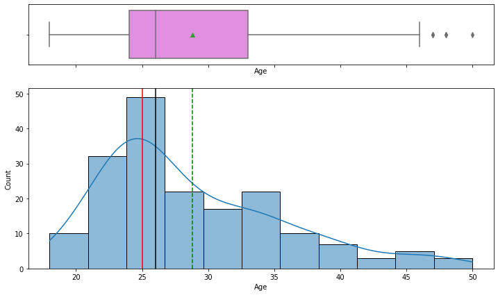

```python
histogram_boxplot(datacgf, 'Age')#applying the function to the Age variable of the dataset
```

```python
datacgf['Age'].mode()
```

```
0    25
dtype: int64
```

Observations : - few outliers (3 out to 180) - data are right skewed - dispersion is limited (46% of people have between 23 and 30 years old). std is 6,9 and IQR is 9 years.

# Education analysis

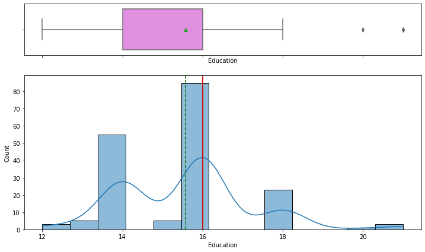

```python
histogram_boxplot(datacgf, 'Education')
```

Observations : - low dispersion of data with a high concentration around 16 years (50% of sample), std of 1,6 and IQR of 2. Mean and Median are close. - skewness is limited here, more right than left however. - two outliers, which is very limited

# Usage Analysis

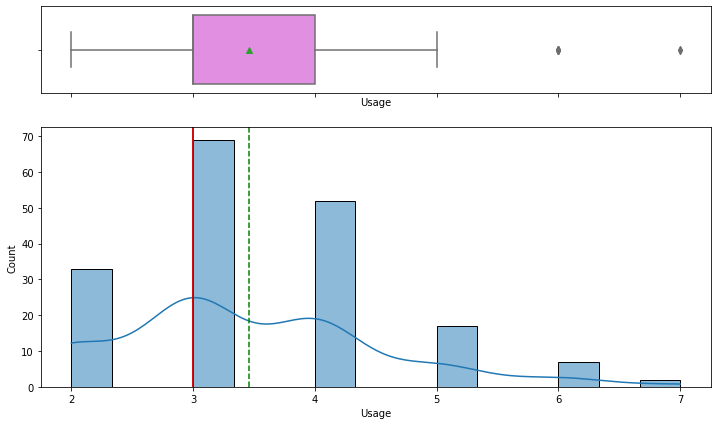

```python
histogram_boxplot(datacgf, 'Usage')
```

Observations : - limited dispersion here, almost half of values are 3, std is 1.08 and IQR 1. Mean and Median close. - right skewed data - two outliers, which is very limited - most of Usage are between 2 and 5 per week

# Fitness analysis

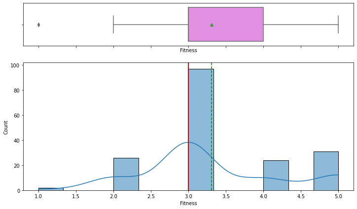

```python
histogram_boxplot(datacgf, 'Fitness')
```

Observations : - limited dispersion here, std and IQR are 1, Mean and Median are close - data looks balanced no real skewness - only one outliers, left one - Most of the people have a Fitness level between 3 and 5

# Income analysis

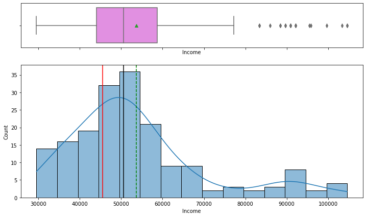

```python
histogram_boxplot(datacgf, 'Income')
```

Observations : - 11 outliers, 6% of data. low level but have to be cautious on this. - low dispersion level,std and IQR are 16500 and 14610 respectively. Mean and Median are close. - data are right skewed

# Miles analysis

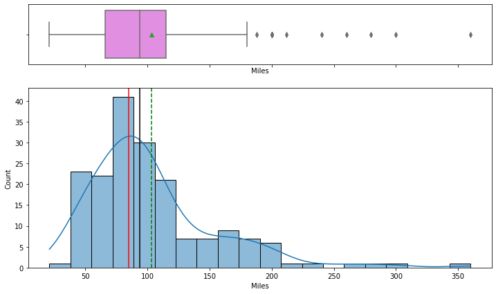

```python
histogram_boxplot(datacgf, 'Miles')
```

Observations : - some outliers, 10, 6% of data. - dispersion is limited as Mean, Median and Mode are close. std and IQR are respectively 51,8 and 48,75. - data are righ skewed

# Gender analysis

```python
#Making a list of all categorical variables
cat_col=['Gender', 'MaritalStatus', 'Product']

#Printing number of count of each unique value in each column
for column in cat_col:
    print(datacgf[column].value_counts())
    print('-'*50)
```

```
Male      104
Female     76
Name: Gender, dtype: int64
--------------------------------------------------
Partnered    107
Single        73
Name: MaritalStatus, dtype: int64
--------------------------------------------------
TM195    80
TM498    60
TM798    40
Name: Product, dtype: int64
--------------------------------------------------
```

```python
# function to create labeled barplots


def labeled_barplot(data, feature, perc=False, n=None):
    """
    Barplot with percentage at the top

    data: dataframe
    feature: dataframe column
    perc: whether to display percentages instead of count (default is False)
    n: displays the top n category levels (default is None, i.e., display all levels)
    """

    total = len(data[feature])  # length of the column
    count = data[feature].nunique()#count unique values
    #this condition below adapt the figsize depending on the unique values
    if n is None:
        plt.figure(figsize=(count + 1, 5))
    else:
        plt.figure(figsize=(n + 1, 5))

    plt.xticks(rotation=90, fontsize=15)
    ax = sns.countplot(
        data=data,
        x=feature,
        palette="Paired",
        order=data[feature].value_counts().index[:n].sort_values(),
    )

    for p in ax.patches:
        if perc == True:
            label = "{:.1f}%".format(
                100 * p.get_height() / total
            )  # percentage of each class of the category
        else:
            label = p.get_height()  # count of each level of the category

        x = p.get_x() + p.get_width() / 2  # width of the plot
        y = p.get_height()  # height of the plot

        ax.annotate(
            label,
            (x, y),
            ha="center",
            va="center",
            size=12,
            xytext=(0, 5),
            textcoords="offset points",
        )  # annotate the percentage

    plt.show()  # show the plot
```

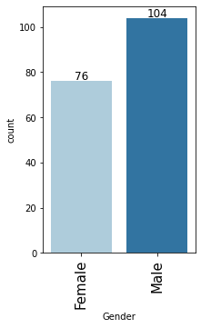

```python
labeled_barplot(datacgf, 'Gender')
```

Observations : - More Male (104) than Female(76) in the dataset

# MaritalStatus Analysis

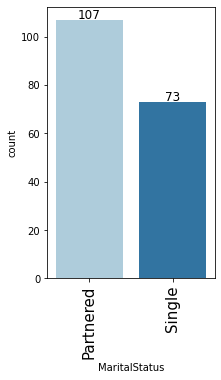

```python
labeled_barplot(datacgf, 'MaritalStatus')
```

Osbervations : - More Partnered (107) than Single(73) in the dataset

# Product Analysis

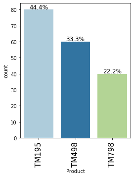

```python
labeled_barplot(datacgf, 'Product', perc=True)
```

Observations : - TM195 is strongly used (44%) vs TM498 (33%) and TM798 (22%)

# Multivariate analysis

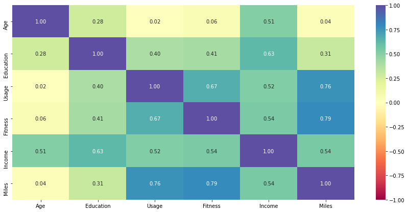

```python
corr = datacgf.corr()#correlation matrix of datacgf

plt.figure(figsize=(15,7))#sizing the figure
#heatmaping the correlation matrix
sns.heatmap(corr, annot=True, vmin=-1, vmax=1, fmt=".2f", cmap="Spectral", xticklabels=corr.columns, yticklabels=corr.columns)
plt.show()#showing result
```

Observations : - Fitness and Usage are correlated to Miles, which make sense. This is positive correlation. - Fitness and Usage are also positively correlated - Income and Education are also positively correlated

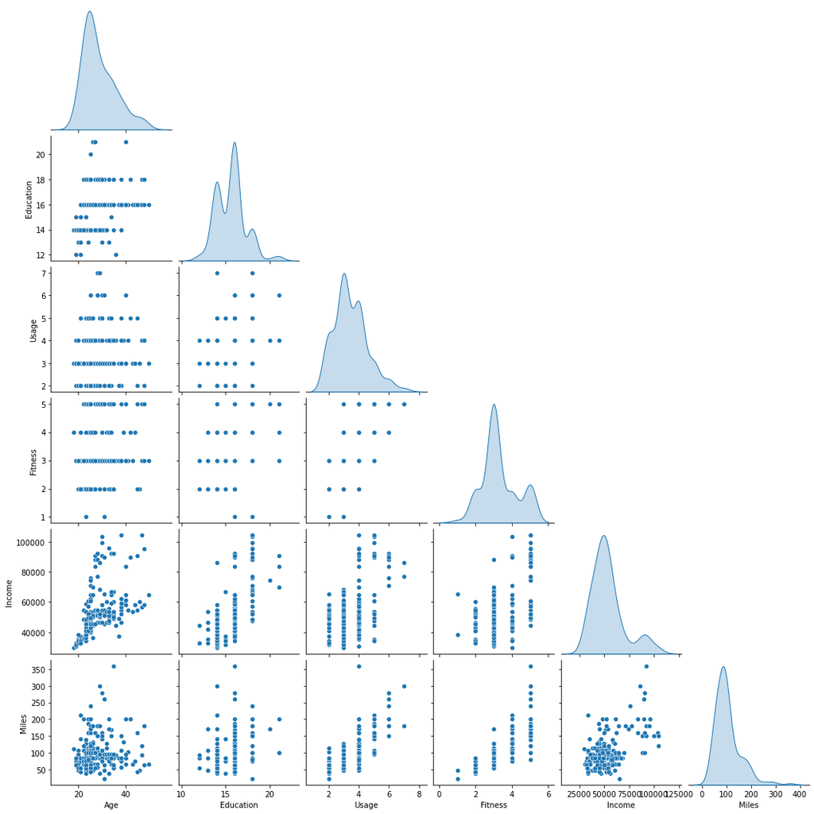

```python
#pairploting datacgf to see any difference with the correlation matrix
sns.pairplot(data=datacgf, diag_kind="kde", corner=True)
plt.show()
```

Observations : - Many discrete variable makes difficult the pairplot interpretation. However, this confirm a "relationship" between Usage, Fitness and Miles as for Usage and Fitness.

# Product TM195 users

```python
df1 = pd.get_dummies(data=datacgf, columns=['Product']) #converting categorical Product variable into boolean
df1.head() #checking result
```

|  | Age | Gender | Education | MaritalStatus | Usage | Fitness | Income | Miles | Product_TM195 | Product_TM498 | Product_TM798 |
| --- | --- | --- | --- | --- | --- | --- | --- | --- | --- | --- | --- |
| 0 | 18 | Male | 14 | Single | 3 | 4 | 29562 | 112 | 1 | 0 | 0 |
| 1 | 19 | Male | 15 | Single | 2 | 3 | 31836 | 75 | 1 | 0 | 0 |
| 2 | 19 | Female | 14 | Partnered | 4 | 3 | 30699 | 66 | 1 | 0 | 0 |
| 3 | 19 | Male | 12 | Single | 3 | 3 | 32973 | 85 | 1 | 0 | 0 |
| 4 | 20 | Male | 13 | Partnered | 4 | 2 | 35247 | 47 | 1 | 0 | 0 |

```python
#keeping only the Product_195 column for further treatments
df2 = df1.filter(items=['Age', 'Usage','Education', 'Fitness', 'Income', 'Gender', 'Miles', 'MaritalStatus', 'Product_TM195'])
df2.head()#checking result
```

|  | Age | Usage | Education | Fitness | Income | Gender | Miles | MaritalStatus | Product_TM195 |
| --- | --- | --- | --- | --- | --- | --- | --- | --- | --- |
| 0 | 18 | 3 | 14 | 4 | 29562 | Male | 112 | Single | 1 |
| 1 | 19 | 2 | 15 | 3 | 31836 | Male | 75 | Single | 1 |
| 2 | 19 | 4 | 14 | 3 | 30699 | Female | 66 | Partnered | 1 |
| 3 | 19 | 3 | 12 | 3 | 32973 | Male | 85 | Single | 1 |
| 4 | 20 | 4 | 13 | 2 | 35247 | Male | 47 | Partnered | 1 |

```python
df3 = df2.query('Product_TM195==1')#keeping only the Product_195 users
df3.head()#checking result
```

|  | Age | Usage | Education | Fitness | Income | Gender | Miles | MaritalStatus | Product_TM195 |
| --- | --- | --- | --- | --- | --- | --- | --- | --- | --- |
| 0 | 18 | 3 | 14 | 4 | 29562 | Male | 112 | Single | 1 |
| 1 | 19 | 2 | 15 | 3 | 31836 | Male | 75 | Single | 1 |
| 2 | 19 | 4 | 14 | 3 | 30699 | Female | 66 | Partnered | 1 |
| 3 | 19 | 3 | 12 | 3 | 32973 | Male | 85 | Single | 1 |
| 4 | 20 | 4 | 13 | 2 | 35247 | Male | 47 | Partnered | 1 |

```python
df3.shape #double checking result
```

```
(80, 9)
```

```python
df3.describe()#statistic summary of the dataset
```

|  | Age | Usage | Education | Fitness | Income | Miles | Product_TM195 |
| --- | --- | --- | --- | --- | --- | --- | --- |
| count | 80.00000 | 80.00000 | 80.00000 | 80.00000 | 80.00000 | 80.00000 | 80.00000 |
| mean | 28.55000 | 3.08750 | 15.03750 | 2.96250 | 46418.02500 | 82.78750 | 1.00000 |
| std | 7.22145 | 0.78262 | 1.21638 | 0.66454 | 9075.78319 | 28.87410 | 0.00000 |
| min | 18.00000 | 2.00000 | 12.00000 | 1.00000 | 29562.00000 | 38.00000 | 1.00000 |
| 25% | 23.00000 | 3.00000 | 14.00000 | 3.00000 | 38658.00000 | 66.00000 | 1.00000 |
| 50% | 26.00000 | 3.00000 | 16.00000 | 3.00000 | 46617.00000 | 85.00000 | 1.00000 |
| 75% | 33.00000 | 4.00000 | 16.00000 | 3.00000 | 53439.00000 | 94.00000 | 1.00000 |
| max | 50.00000 | 5.00000 | 18.00000 | 5.00000 | 68220.00000 | 188.00000 | 1.00000 |

Observations : - Our customer profile, in average, is aged 28,5,use 3 time a week in average the TM_195 Product, he or she has 15 years of education, he or she as a 3 Fitness level, he or she earns 46418$ a year in average and runs 82 Miles in average.

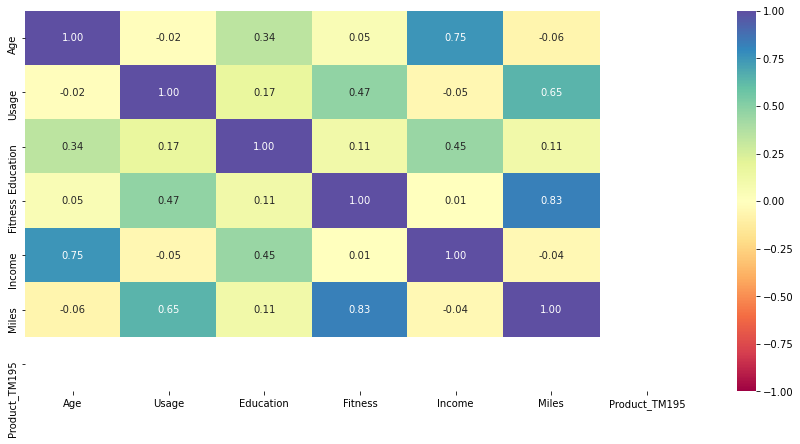

```python
corr = df3.corr()#correlation matrix of our TM_195 users

plt.figure(figsize=(15,7))#sizing the figure
#heatmaping the correlation matrix
sns.heatmap(corr, annot=True, vmin=-1, vmax=1, fmt=".2f", cmap="Spectral", xticklabels=corr.columns, yticklabels=corr.columns)
plt.show()
```

Observations : - In this group we have strong correlation between Miles and Fitness and between Age and Income - In this group Income is more correlated with Age than Education

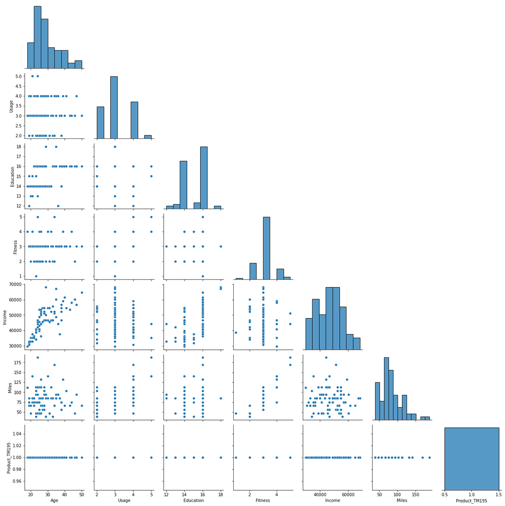

```python
sns.pairplot(data=df3, corner=True)
```

Observations : - pairplots confirm heatmap conclusions

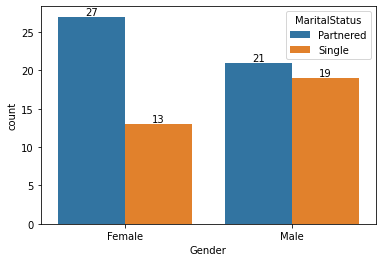

```python
ax = sns.countplot(x='Gender', hue='MaritalStatus', data=df3) #defining a countplot for Gender and MaritalStatus

for p in ax.patches: #printing value of each plot
    label = p.get_height()
    x = p.get_x() + p.get_width() / 2  # width of the plot
    y = p.get_height()  # height of the plot
    ax.annotate(label, (x,y), ha='center', va='center', size=10, xytext=(0,5), textcoords='offset points')

plt.show()#printing the graph
```

Observations : - There are more Female Partnered than Male partnered in this group (27 to 40 vs 21 to 40) in relative and nominal values - Male and Female number is the same (40)

```python
def labeled_boxplot(data, feature):

    #building arrays with median, quantile25 and quantile75 values of our sample
    median = data.groupby(by=['Gender', 'MaritalStatus'])[feature].median().values
    quantile25 = data.groupby(by=['Gender', 'MaritalStatus'])[feature].quantile(q=0.25).values
    quantile75 = data.groupby(by=['Gender', 'MaritalStatus'])[feature].quantile(q=0.75).values

    #reordering data within arrays (boxplot and groupby are not ordering values in the same way)
    median_array = (median[1], median[0], median[3], median[2])
    quantile25_array = (quantile25[1], quantile25[0], quantile25[3], quantile25[2])
    quantile75_array = (quantile75[1], quantile75[0], quantile75[3], quantile75[2])

    #Boxploting Gender, MaritalStatus and feature for data
    ax = sns.boxplot(x='Gender', y=feature, hue='MaritalStatus', data=data)

    #putting into variables the median, quantile25 and quantile75
    a = median_array
    b = quantile25_array
    c = quantile75_array

    #implementing counter
    ind = 0
    #showing Median value on boxplot

    for tick in range(len(ax.get_xticklabels())):
        ax.text(tick-.2, a[ind+1], a[ind+1], horizontalalignment='center', size=10, color='b')
        ax.text(tick+.2, a[ind], a[ind], horizontalalignment='center', size=10, color='b')
        ind+=2

    #showing quantile25 on Boxplot
    ind = 0
    for tick in range(len(ax.get_xticklabels())):
        ax.text(tick-.4, b[ind+1], b[ind+1], horizontalalignment='left', size=10, color='b')
        ax.text(tick, b[ind], b[ind], horizontalalignment='left', size=10, color='b')
        ind+=2

    #showing quantile75 on Boxplot
    ind=0
    for tick in range(len(ax.get_xticklabels())):
        ax.text(tick-.4, c[ind+1], c[ind+1], horizontalalignment='left', size=10, color='b')
        ax.text(tick, c[ind], c[ind], horizontalalignment='left', size=10, color='b')
        ind+=2

    plt.show()
```

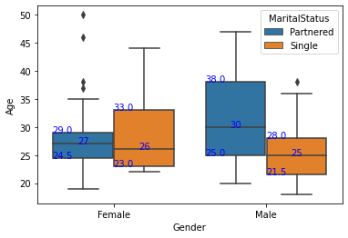

```python
labeled_boxplot(df3, 'Age')#boxploting TM_195 users with Age, Gender and MaritalStatus
```

Observations : - Partnered Male are more aged than Single Male in this group - Partnered Male are the oldest of the sample - Single Female and partnered Female have a close age - Many outliers in relative (4 on 27) in the Female partnered group

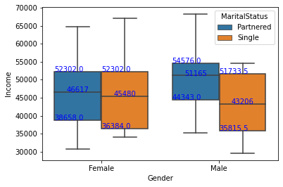

```python
labeled_boxplot(df3, 'Income')#boxploting TM_195 users with Income, Gender, MaritalStatus
```

Observations : - Partnered Male Income is higher than Single Male Income - No difference between Partnered Female and Single Female - not really surprising as Income is correlated with Age (Partnered Men are the oldest of the sample) - No Outliers

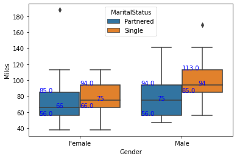

```python
labeled_boxplot(df3, 'Miles')#boxploting TM_195 with Miles, Gender, MaritalStatus
```

Observations : - Single Male and Single Female have a higher Miles Median than Partnered ones, respectively.

```python
#defining a function to compare discrete variables
def feature_interactions(df,feature1, feature2,continuous_col):
    #selecting the group of data needed with the 2 discrete variable (feature1, feature2) and the continuous one (continuous col)
    group = df.groupby([feature1,feature2],as_index=False)[continuous_col].mean().reset_index(drop=True)
    #pivoting table with feature 1 as y and feature 2 as x
    pivot = group.pivot(index=feature1, columns=feature2, values=continuous_col)
    #sizing the figure
    plt.figure(figsize=(10,6))
    #ploting with heatmap
    sns.heatmap(pivot,cmap='Reds')
    #showing the graph
    plt.show()
```

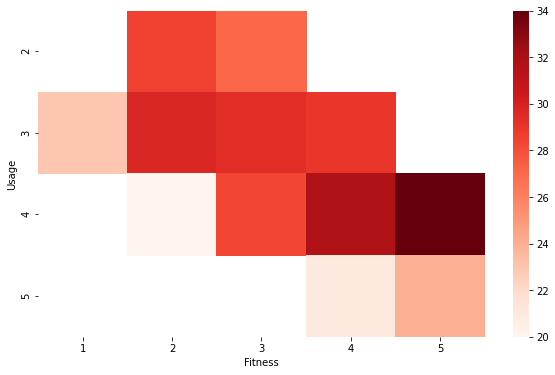

```python
feature_interactions(df3, 'Usage', 'Fitness', 'Age') #heatmaping discrete variables Usage and Fitness in regard to continous Age variable
```

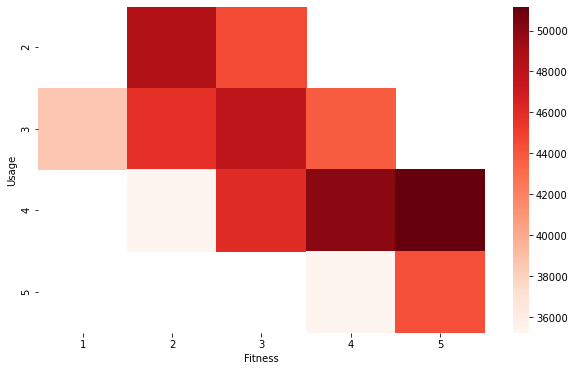

```python
feature_interactions(df3, 'Usage', 'Fitness', 'Income')#heatmaping discrete variable Usage and Fitness in regard with continous variable Income
```

Observations : - The highest income are overrepresented in the highest Fitness/Usage levels. This make sense as there is a correlation between Age and Income.

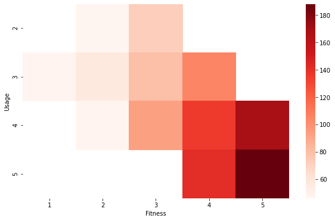

```python
feature_interactions(df3, 'Usage', 'Fitness', 'Miles')#heatmaping discrete variable Usage and Fitness in regard to Miles continuous variable
```

Observations : - The higher the Miles level is the better the higher the Fitness and Usage are.Conclusions on TM195 users : - They are equally Male or Female (50/50) - They are more partnered than single - The oldest Male are Partnered while the youngest are Single - The oldest Male have the higher Income as Income is correlated with Age - The Female groups have no difference in Age or Income - The Single ones run more Miles than the Partnered ones - In this group Miles is correlated with Usage and Fitness

# TM498 user group

```python
df4 = df1.filter(items=['Age', 'Usage','Education', 'Fitness', 'Income', 'Gender', 'Miles', 'MaritalStatus', 'Product_TM498'])
#keeping the Product_498 column for further treatments
df4.head()#checking result
```

|  | Age | Usage | Education | Fitness | Income | Gender | Miles | MaritalStatus | Product_TM498 |
| --- | --- | --- | --- | --- | --- | --- | --- | --- | --- |
| 0 | 18 | 3 | 14 | 4 | 29562 | Male | 112 | Single | 0 |
| 1 | 19 | 2 | 15 | 3 | 31836 | Male | 75 | Single | 0 |
| 2 | 19 | 4 | 14 | 3 | 30699 | Female | 66 | Partnered | 0 |
| 3 | 19 | 3 | 12 | 3 | 32973 | Male | 85 | Single | 0 |
| 4 | 20 | 4 | 13 | 2 | 35247 | Male | 47 | Partnered | 0 |

```python
df5 = df4.query('Product_TM498==1')#selecting the TM_498 Product users only
df5.head()
```

|  | Age | Usage | Education | Fitness | Income | Gender | Miles | MaritalStatus | Product_TM498 |
| --- | --- | --- | --- | --- | --- | --- | --- | --- | --- |
| 80 | 19 | 3 | 14 | 3 | 31836 | Male | 64 | Single | 1 |
| 81 | 20 | 2 | 14 | 3 | 32973 | Male | 53 | Single | 1 |
| 82 | 20 | 3 | 14 | 3 | 34110 | Female | 106 | Partnered | 1 |
| 83 | 20 | 3 | 14 | 3 | 38658 | Male | 95 | Single | 1 |
| 84 | 21 | 5 | 14 | 4 | 34110 | Female | 212 | Partnered | 1 |

```python
df5.shape#cheking results
```

```
(60, 9)
```

```python
df5.describe()#statistical description of the TM_498 users
```

|  | Age | Usage | Education | Fitness | Income | Miles | Product_TM498 |
| --- | --- | --- | --- | --- | --- | --- | --- |
| count | 60.00000 | 60.00000 | 60.00000 | 60.00000 | 60.00000 | 60.00000 | 60.00000 |
| mean | 28.90000 | 3.06667 | 15.11667 | 2.90000 | 48973.65000 | 87.93333 | 1.00000 |
| std | 6.64525 | 0.79972 | 1.22255 | 0.62977 | 8653.98939 | 33.26314 | 0.00000 |
| min | 19.00000 | 2.00000 | 12.00000 | 1.00000 | 31836.00000 | 21.00000 | 1.00000 |
| 25% | 24.00000 | 3.00000 | 14.00000 | 3.00000 | 44911.50000 | 64.00000 | 1.00000 |
| 50% | 26.00000 | 3.00000 | 16.00000 | 3.00000 | 49459.50000 | 85.00000 | 1.00000 |
| 75% | 33.25000 | 3.25000 | 16.00000 | 3.00000 | 53439.00000 | 106.00000 | 1.00000 |
| max | 48.00000 | 5.00000 | 18.00000 | 4.00000 | 67083.00000 | 212.00000 | 1.00000 |

Observations : - our customer profile, in average, is close to 29 year old, use 3 time a week the TM_498 Product, as a 15 years education level, as a close to 3 Fitness level, earn 48 973$ per year and run close to 88 Miles - TM_498 customer profile is very close to the TM_195

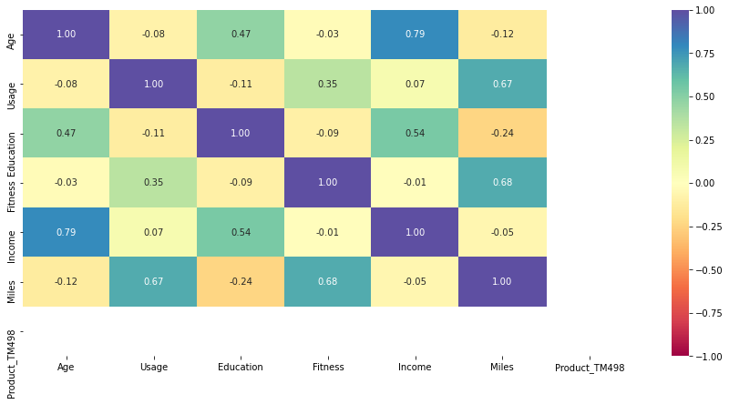

```python
corr = df5.corr()#correlation calculation of df5 dataframe

plt.figure(figsize=(15,7))#sizing the graph
#heatmaping the TM_498 correlation matrix
sns.heatmap(corr, annot=True, vmin=-1, vmax=1, fmt=".2f", cmap="Spectral", xticklabels=corr.columns, yticklabels=corr.columns)#heatmaping the correlation results
plt.show()
```

Observations : - Income and Age are correlated, as in TM_195 group - Usage and Fitness are correlated to Miles, as in TM_195 group - Here again very close profile than the TM_195 group

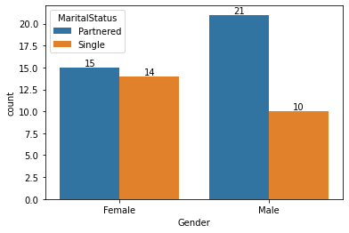

```python
ax = sns.countplot(x='Gender', hue='MaritalStatus', data=df5) #defining a countplot for Gender and MaritalStatus

for p in ax.patches: #printing value of each plot
    label = p.get_height()
    x = p.get_x() + p.get_width() / 2  # width of the plot
    y = p.get_height()  # height of the plot
    ax.annotate(label, (x,y), ha='center', va='center', size=10, xytext=(0,5), textcoords='offset points')

plt.show()#printing the graph
```

Observations : - In this group Male and Female are balanced (31 Male for 29 Female) - More Partnered than single ones as in TM_195 group

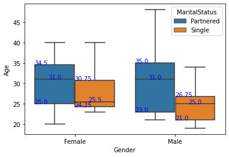

```python
labeled_boxplot(df5, 'Age')#boxploting TM_498 users with Age, Gender, MaritalStatus
```

Observations : - The partnered ones (both Male and Female) are older than the Single ones

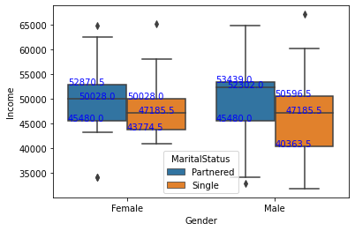

```python
labeled_boxplot(df5, 'Income')#boxploting TM_498 users with Income, Gender, MaritalStatus
```

Observations : - with no surprise, Partnered Income (both Male and Female) are higher than Single Income ones. As a reminder Age and Income are correlated in this group - difference between Partnered and Single is low in both relative and absolute terms in both Male and Female groups - small difference between Partnered Male and Female in both absolute and relative terms

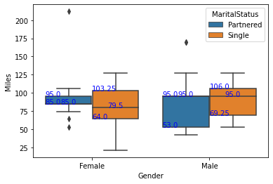

```python
labeled_boxplot(df5, 'Miles')#boxploting TM_498 users with Miles, Gender, MaritalStatus
```

Observations : - No real difference here

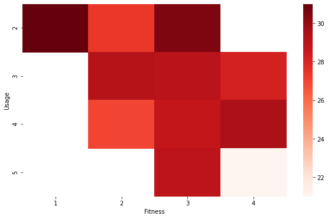

```python
feature_interactions(df5, 'Usage', 'Fitness', 'Age')#heatmaping Usage, Fitness with Age
```

Observations : - The youngest have the highest Fitness and Usage level - The oldest have the lower Fitness and Usage level

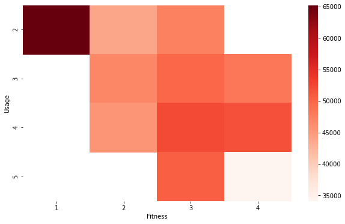

```python
feature_interactions(df5, 'Usage', 'Fitness', 'Income')#heatmaping TM_498 users with Usage, Fitness and Income
```

Observations : - The higher income have the lowest Usage/Fitness level, so the oldest ones as Age is correlated with Income - The lower income have the higher Usage/Fitness level, so the youngest ones as Age is correlated with Income

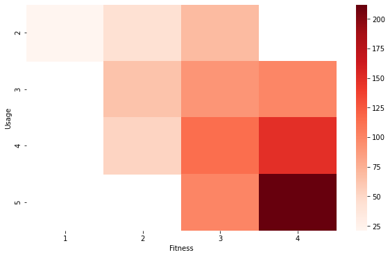

```python
feature_interactions(df5, 'Usage', 'Fitness', 'Miles')
```